# Estimation of lattice energies of simple inorganic solids

$\require{mhchem}$

# Comments on the assessment

Full details about how this project is assessed can be found in the guidance document on Learn, but key points are:

- Each Jupyter cell should run.
- Marks will be awarded for producing the correct output.
- Every function you write should have an appropriate doc-string.
- All plots should be labelled correctly and all fonts should have a legible size.
- Markdown should be used to explain concepts and answer discussion questions.

Reminder: Comment your code, use markdown to explain your working where appropriate, and make sure all your variable names are sensible! Also make sure to choose appropriate levels of significant figures for print out and make sure you use the correct units.

# Introduction

The stability of the crystal structure of a 1:1 salt $AX$ is expressed by the free energy for the process:
$AX_{(s)}$ -> $A^{+}$$_{(g)}$ + $X^{-}$$_{(g)}$
which corresponds to the sublimation of the solid into a gas consisting of cations and anions.
Equivalent equations can be written down for the sublimation of salts with other stoichiometries. The enthalpy contribution to this process is much larger than the entropy contribution, and it is usual to approximate the treatment of the thermodynamic stability of ionic solids using the enthalpy contribution alone.

Formally the *lattice enthalpy* is the value of $ΔH$ for the process given in the equation above, but it is common to describe the same quantity as a lattice energy, as though it was the same as the change in the internal energy of the process ($ΔU$).  
Lattice energies are by convention quoted as positive quantities, i.e. referring to the solid -> gas transition. The more positive a lattice energy, the more stable the crystal structure.

This mini-project looks at the many ways in which you can calculate or experimentally determine lattice energies of some simple inorganic salts. In particular, the project explores how the lattice energy changes as a function of cation or anion size and stoichiometry.

# Calculating the lattice enthalpy

## Technical notes

### Docstrings

- Docstrings used in this project are adapted from Google's python docstring style.

### Some common abbreviations used in the assessement:

- _bm : refers to lattice energies calculated using the Born-Mayer equation
- _k : refers to lattice energies calculated using the Kapustinskii equation
- _exp : refers to lattice energies obtained experimentally

### Part 1: Born-Mayer

The Born–Mayer equation is used to estimate lattice enthalpy for an ionic lattice.The Madelung constant, $A$, reﬂects the eﬀect of the geometry of the lattice on the strength of the net Coulombic interaction.

$\Delta _{L} H = \frac{N_{A} \left | z{_{A}} z{_{B}}\right | e^{2}}{4\pi \varepsilon _{0}d}\left ( 1-\frac{d^{*}}{d} \right )A$

Where $z{_{A}}$ is the charge on the cation and $z{_{B}}$ the charge on the anion, which are separated by a distance of $d$. $A$ is the Madelung constant, $e$ is the elementary charge of a particle and $d{^{*}}$ a constant equal to 0.345 $Å$.

The separation distance, $d$, can be calculated knowing both the packing of the ionic structure and the lattice parameter.

Packing for face-centred cubic (FCC) and body-centred cubic (BCC) crystal structures are shown in Figure 1. The separation distance, $d$, for both packing is different. For FCC: $d$ is simply 1/2 of the unit cell length, $a$, whereas for BCC, $2d$ is equal to $a\sqrt{3}$.

[figure not shown]

## Task 1: (14 marks)

Within the file `lattice_data.csv`, you have a range of inorganic solids and some parameters needed to calculate the lattice energy, you may need to calculate some parameters from those given.

Firstly, write a function that computes the lattice energy with the Born-Mayer equation, paying close attention to the units.

Secondly, use that function to work out the lattice energy for the list of inorganic solids listed within `lattice_data.csv`.

Finally, programatically add the resulting lattice energy to the `lattice_data.csv` file as an extra column of data, where the final unit will be $kJ mol^{-1}$.

```python
#importing all libraries used for the assignement
import math as m
import pandas as pd
import re
import matplotlib.pyplot as plt
import numpy as np
from scipy import constants
%matplotlib inline
```

The `separation_distance()` function calculates the ceparation distance $d$ from the lattice parameter $a$ according to the following chemical rules:

### Body-centered cubic

$2d=a\sqrt{3}$  
$d=\dfrac{a\sqrt{3}}{2}$

### Face-centered cubic

$d=\dfrac{a}{2}$

```python
def separation_distance(packing, a):
    '''
    Calculates the separation distance d from the lattice parameter and the type of packing.

    Args:
        packing: string
            Type of packing. Accepted inputs 'bcc' for body centered cubic and 'fcc' for face centered cubic.
        a: float
            Lattice parameter in Å.

    Returns:
        float
            The separation distance d.

    Raises:
        AssertionError: If packing is not either fcc or bcc.
    '''


    assert packing in ['fcc', 'bcc'], 'your packing type is invalid - it should either be fcc or bcc.'

    # if, elif statement to calculate the separation distance.
    if packing == 'fcc':
        return a/2
    elif packing == 'bcc':
        return (a*m.sqrt(3))/(2)
```

The `born_mayer()` function calculates the lattice energy using the Born Mayer equation.

```python
def born_mayer(ZA, ZB, Madelung_Constant, Packing, Lattice_Parameter):
    '''
    Calculates the lattice energy using the Born-Mayer equation.

    Args:
        ZA: float
            Charge of the cation in units of e.
        ZB: float
            Charge of the anion in units of e.
        Madelung_Constant: float
            The Madelung constant A.
        Packing: string
            Type of packing. Accepted inputs 'bcc' for body centered cubic and 'fcc' for face centered cubic.
        Lattice_Parameter: float
            Lattice paramenter a in Å.

    Returns:
        float
            Lattice energy in units of kJ mol^-1
    Raises:
        AssertionError: If arguments are not of expected types.

    '''


    #assertions to check correct type of inputs
    assert isinstance(float(ZA), float), 'ZA must be a float/integer'
    assert isinstance(float(ZB), float), 'ZB must be a float/integer'
    assert isinstance(float(Madelung_Constant), float), 'Madelung_Constant must be a float/integer'
    assert isinstance(Packing, str), 'Packing must be a string'
    assert isinstance(float(Lattice_Parameter), float), 'Lattice_Parameter must be a float/integer'

    #constants:
    N_a = constants.Avogadro # molecules per mole ; Avogadro constant
    e = constants.elementary_charge # A s ; elemental charge
    e_o = constants.epsilon_0 # kg^-1 m^-3 s^4 A^2 ; permitivity of free space
    d_star = 0.345 # Å

    #variables:
    A = Madelung_Constant
    d = separation_distance(Packing, Lattice_Parameter) #Å

    #calculating the energy in units of J mol^-1
    energy_Jmol = ((N_a*abs(ZA*ZB)*(e**2))/(4*m.pi*e_o*d*10**(-10)))*(1-d_star/d)*A #note the *10**-10 to convert d into meters from Å #J mol^-1

    return energy_Jmol / 1000 #dividing by 1000 to get units of kJ mol^-1
```

The next two cells

- read the `lattice_data.csv` data as a dataframe `df_bm`
- use the entries in `df_bm` as arguments for `born_mayer()`
- save the calculated enthalpies as a new column to `df_bm`
- save `df_bm` as `lattice_data.csv`, thus overwriting the original data

```python
#ingest data
df_bm = pd.read_csv('lattice_data.csv')   #df_bm for dataframe Born-Mayer
```

```python
Lattice_Energy_bm = []

#the for loop calculates the lattice energies of the inorganic solids
#with the born_mayer() function and appends them to Lattice_Energy_bm
#foo is an internal variable
for i in range(len(df_bm.index)):
    foo = born_mayer(df_bm.at[i,'ZA'],
                     df_bm.at[i,'ZB'],
                     df_bm.at[i,'Madelung_Constant'],
                     df_bm.at[i,'Packing'],
                     df_bm.at[i,'Lattice_Parameter'])
    Lattice_Energy_bm.append(foo)

#adding Lattice_Energy_bm to df_bm as a new column
df_bm['Lattice_Energy_Born_Mayer'] = Lattice_Energy_bm

#saving df_bm to csv
df_bm.to_csv('lattice_data.csv', index=False)
```

### Part 2: Kapustinskii

The Born-Mayer equation can be simplified further by recognising that the value of A divided by the number of ions in one formula unit ($N_{ion}$) is approximately constant. The resulting Kapustinskii equation provides a rough and ready way to calculate lattice energies in the absence of any structural information:

$\Delta H_{L} = \kappa \frac{N_{ion} \left | z_{+}z_{-} \right |}{d} \left ( 1 - \frac{d*}{d} \right )$

Where, $\kappa$ is the Kapustinskii parameter which is fixed at $1.21 \times 10^{5}$ $kJ pm\ mol^{-1}$, $N_{ion}$ is the number of ions in a formula unit, $d^{*}$ is still fixed 0.345 $Å$.

## Task 2 (16 marks)

Write a function which will now compute the lattice energy *via* the Kapustinskii equation, (hint: you will also need to work out what $N_{ion}$ is!) again take care to standardise units so that your final lattice energy is in $kJ mol^{-1}$. Use this function to calculate the lattice energy for the list of inorganic solids contained within `lattice_data.csv` and append the energy to the csv file which you wrote out in the task above.

The Kapustinskii equation requires $N_{ion}$ of a certain lattice, so the `N_ion_calc()` function determines that from the string formula of the lattice.

It uses regular expressions to extract all numbers from a string and then assesses them using an `if`, `elif` loop.

- If there are no numbers present in the formula, that means that there is one atom of each component in a formula unit (e.g. NaCl has $N_{ion}=2$)
- If there is only one number present in the formula, this means that one of the components contributes one ion to the formula unit and the other contributes a certain number of ions. (e.g. $\mathrm{CaF_{2}}$ has $N_{ion}=1+2=3$)
- If there are two numbers present in the formula, they are added together - each represents the number of ions each of the components contributes to a formula unit (e.g. $\mathrm{Cr_{2}(SO_{4})_{3}}$ would have $N_{ion}=2+3=5$)
- If there are more than two numbers presnt in the formula, the function raises an error since this is not a simple binary ionic solid

```python
def N_ion_calc(Symbol):
    '''
    Calculates the value of N_ion, the number of ions in one formula unit from the formula of the inorganic solid.
    Uses regex to identify numbers in the formula and returns the number of ions in the formula.

    Args:
        Symbol: string
            The formula of an inorganic solid - e.g. CaF2.

    Returns:
        float:
            Number of ions in one formula unit

    Raises:
        AssertionError: If Symbol is not a string.
        AssertionError: the input string contains more than two numbers, which would imply this is not a binary inorganic solid.
    '''


    assert isinstance(Symbol, str), 'The input must be a string'

    #identify positive integers in the Symbol string and add them to a list
    #The following 2 lines of code were modified from https://www.geeksforgeeks.org/python-extract-numbers-from-string/
    internal = re.findall(r'\d+', Symbol)
    numbers = list(map(int, internal))

    assert len(numbers) <= 2, 'The input does not appear to be a binary formula. N_ion_calc can only find N_ion for binary formulas.'

    #if there are no numbers, the solid only has two ions per formula unit
    if len(numbers) == 0:
        return 2
    #if there is only one number, one ion in the solid contributes one ion, which is added to the number of the other one
    elif len(numbers) == 1:
        return 1 + numbers[0]
    #if there are two numbers detected, they are summed together to return the number of ions in a formula unit (both have >1)
    elif len(numbers) == 2:
        return numbers[0] + numbers[1]
```

The `kapustinskii()` function calculates the lattice energy using the Kapustinskii equation.

```python
def kapustinskii(ZA, ZB, Symbol, Packing, Lattice_Parameter):
    '''
    Calculates the lattice energy using the Kapustinskii equation.

    Args:
        ZA: float
            Charge of the cation in units of e.
        ZB: float
            Charge of the anion in units of e.
        Symbol: string
            The formula of an inorganic solid - e.g. CaF2.
        Packing: string
            Type of packing. Accepted inputs 'bcc' for body centered cubic and 'fcc' for face centered cubic.
        Lattice_Parameter: float
            Lattice paramenter a in Å.

    Returns:
        float
            Lattice energy in units kJ mol^-1
    '''


    #assertions to check correct type of inputs
    assert isinstance(float(ZA), float), 'ZA must be a float/integer'
    assert isinstance(float(ZB), float), 'ZB must be a float/integer'
    assert isinstance(Packing, str), 'Packing must be a string'
    assert isinstance(float(Lattice_Parameter), float), 'Lattice_Parameter must be a float/integer'

    #constants
    kappa = 1.21 * 10**5 # kJ pm mol^-1 ; Kapustinskii parameter
    d_star = 0.345 # Å


    #variables
    N_ion = N_ion_calc(Symbol)
    d = separation_distance(Packing, Lattice_Parameter) # Å

    #The actual calculation is in the return statement
    #the 0.01 is there to account for the fact that kappa is in picometers and d is in Å
    #-> to cancel out the value must be multiplied by 0.01
    return 0.01 * kappa * ((N_ion*abs(ZA*ZB))/(d))*(1-d_star/d)
```

The next two cells

- read the `lattice_data.csv` data as a dataframe `df_k`
- use the entries in `df_k` as arguments for `kapustinkskii()`
- save the calculated enthalpies as a new column to `df_k`
- save `df_k` as `lattice_data.csv`, thus overwriting the original data

```python
#ingest data
df_k = pd.read_csv('lattice_data.csv') #df_k for dataframe kapustinskii
```

```python
#creating an empty list that energy values will be appended to
Lattice_Energy_k = []

#the for loop calculates the lattice energies of the inorganic solids
#with the kapustinskii() function and appends them to Lattice_Energy_k
#var is an internal variable
for i in range(len(df_k.index)):
    var = kapustinskii(df_k.at[i,'ZA'],
                       df_k.at[i,'ZB'],
                       df_k.at[i,'Symbol'],
                       df_k.at[i,'Packing'],
                       df_k.at[i,'Lattice_Parameter'])
    Lattice_Energy_k.append(var)

#The list Lattice_Energy_k is added as a new column to df_k
df_k['Lattice_Energy_Kapustinskii'] = Lattice_Energy_k

#saving df_k to csv
df_k.to_csv('lattice_data.csv', index=False)
```

## Task 3 (marks 14)

Now that you have calculated the lattice enthalpy via 2 methods, please compare them with the experimental values which are contained within the `experimental_lattice_data.csv` file. You should work out the difference between:

- the two computational methods
- each computational method with the experimental method

and plot the 3 lattice energies for each structure.

If you could not produce lattice energies via the Born-Mayer or Kapustinskii equations, you can use the data provided in `BM_lattice_data.csv` and `K_lattice_data.csv`, respectively.

In a markdown cell, determine and reason the trends you see in lattice energy. Please also explain the reasoning behind the differences seen between the three methods of determining the lattice energy.

```python
#ingest data

#reads in the csv that was modified in the previous two steps
computational = pd.read_csv('lattice_data.csv')

#reads in the values of the experimentally obtained lattice energies
experimental = pd.read_csv('experimental_lattice_data.csv')
```

The following cell

- calculates the differences between:
  - the two computational methods
  - each computational method with the experimental method
- creates a new dataframe `presentation` with the most relevant columns, including the differences
- multiplies the differences by 100 % to get the percentage differences
- presents them in an html table with 2 decimal points of precision

```python
# calculating the differences beteen the different methods of obtaining the lattice energies
bm_minus_k = computational['Lattice_Energy_Born_Mayer'] - computational['Lattice_Energy_Kapustinskii']
exp_minus_bm = computational['Lattice_Energy_Born_Mayer'] - experimental['Lattice_energy_exp']
exp_minus_k = computational['Lattice_Energy_Kapustinskii'] - experimental['Lattice_energy_exp']

#manually fixing the symbols for CaF2 and Cu2O to make sure they appear with the subscripted number
computational['Symbol', 8] = r'CaF$_2$'
computational['Symbol', 9] = r'Cu$_2$O'

#concactenating a dataframe from the calculated differences and the original values
presentation =  pd.concat([computational['Symbol'],
                           bm_minus_k,
                           exp_minus_bm,
                           exp_minus_k,
                           computational['Lattice_Energy_Born_Mayer'],
                           computational['Lattice_Energy_Kapustinskii'],
                           experimental['Lattice_energy_exp']], axis=1)

#setting the column names
presentation.columns = ['Lattice',
                        'bm_minus_k',
                        'exp_minus_bm',
                        'exp_minus_k',
                        'bm',
                        'k',
                        'exp']

#calculating the percentage differences =
presentation['Born-Mayer minus Kapustinskii / %'] = (presentation['bm_minus_k'] / presentation['bm']) * 100
presentation['Experimental minus Born-Mayer / %'] = (presentation['exp_minus_bm'] / presentation['exp']) * 100
presentation['Experimental minus Kapustinskii / %'] = (presentation['exp_minus_k'] / presentation['exp']) * 100


#modifying the settings to only show two decimal points
pd.set_option('precision', 2)

#saves the desired columns to a new df and presents it using the HTML functionality in Jupyter
table = presentation[['Lattice',
                      'Born-Mayer minus Kapustinskii / %',
                      'Experimental minus Born-Mayer / %',
                      'Experimental minus Kapustinskii / %']]

#the table is not printed here, but below the plot in order to be quickly referencable.
```

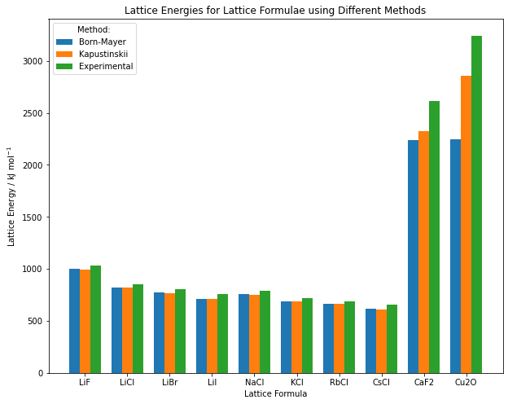

```python
#plotting

#Create plot and axis
fig = plt.figure(figsize=(10, 8))
ax = fig.add_subplot()

#Manually creating the locations of the ticks on the x-axis (in order to be able to plot a grouped bar-chart)
x = np.arange(len(computational['Symbol']))

#saving the symbols that will be used as labels on the x-axis to a list
x_labels = list(computational['Symbol'])

#The next 6 lines of code are adapted from the documentation here
#https://matplotlib.org/stable/gallery/lines_bars_and_markers/barchart.html
#plotting grouped bar charts by shifting the bm bars to the left by w and the experimental bars to the right by w
w = 0.25
rects1 = ax.bar(x-w, computational['Lattice_Energy_Born_Mayer'], width = 0.25, label = 'Born-Mayer')
rects2 = ax.bar(x, computational['Lattice_Energy_Kapustinskii'], width = 0.25, label = 'Kapustinskii')
rects3 = ax.bar(x+w, experimental['Lattice_energy_exp'], width = 0.25, label = 'Experimental')

#setting the locations of the x-ticks and then adding the (modified) labels
ax.set_xticks(x)
ax.set_xticklabels(x_labels)

#setting axis labels
ax.set_xlabel('Lattice Formula')
ax.set_ylabel(r'Lattice Energy / $\mathrm{kJ\ mol^{-1}}$')

#adding a legend
ax.legend(title = 'Method:')

#adding a title
ax.set_title('Lattice Energies for Lattice Formulae using Different Methods'); # ; to stop matplotlib from printing data
```

```python
table #prints the html table created above, but making sure it is below the graph and thus easily accessible
      #while reading the trends and differences section
```

|  | Lattice | Born-Mayer minus Kapustinskii / % | Experimental minus Born-Mayer / % | Experimental minus Kapustinskii / % |
| --- | --- | --- | --- | --- |
| 0 | LiF | 0.35 | -2.96 | -3.31 |
| 1 | LiCl | 0.35 | -3.77 | -4.11 |
| 2 | LiBr | 0.35 | -4.39 | -4.72 |
| 3 | LiI | 0.35 | -5.71 | -6.04 |
| 4 | NaCl | 0.35 | -3.75 | -4.09 |
| 5 | KCl | 0.35 | -3.78 | -4.12 |
| 6 | RbCl | 0.35 | -3.96 | -4.30 |
| 7 | CsCl | 1.20 | -5.76 | -6.89 |
| 8 | CaF2 | -3.72 | -14.31 | -11.12 |
| 9 | Cu2O | -26.83 | -30.65 | -12.04 |

## Trends in Lattice Energy

1. The lattice energies increase with increased charge. This is clearly visible from the plot above, where $\mathrm{CaF_{2}}$ and $\mathrm{Cu_{2}O}$ have much higher lattice energies than all the other lattices. $\mathrm{CaF_{2}}$ and $\mathrm{Cu_{2}O}$ each contain an ion with charge $+2$ or $-2$, while all the other lattices only contain singly charged ions.
2. Lattice energies also increase with smaller separation distances. This is also clearly visible from the plot above. $\mathrm{Li^{+}}$ and $\mathrm{F^{-}}$ in $\mathrm{LiF}$ both have sery small radii, so their lattice energies are quite large. On the other hand, $\mathrm{Cs^{+}}$ and $\mathrm{Cl^{-}}$ in $\mathrm{CsCl}$ are in higher periods on the periodic table and thus have much larger radii, resulting in a ~40 % smaller lattice energy than $\mathrm{LiF}$. Other lattices in the dataset containing only singly charged ions follow this trend.

These two trends are the result of the mechanism of the coulomb force, which is the reason why the lattice energies exist. The coulomb force between two ions is given by

$F=k_{e}\dfrac{q_{1}q_{2}}{r^{2}}$,

where $k_{e}$ is a constant, $q_{1}$ and $q_{2}$ are the charges of the two particles and $r$ is the distance between them.

- If either of $q_{1}$ and $q_{2}$ increase, the coulomb force and thus the lattice energy will increase, as described in (1)
- If $r$ increases (down the group in the periodic system), the coulomb force and thus the lattice energy will decrease, as described in (2)

Furthermore, the errors between the experimental errors for lattices containing only singly charged ions are larger when the ions are most polarisable (e.g. in $\mathrm{CsCl}$) and smallest in lattices with the least polarisable ions (e.g. in $\mathrm{LiF}$).

## Differences between the three methods

#### Observations:

- The error between the computational and experimental methods is quite small for rows 0-7, but gets quite large in rows 8-9
- The Born-Mayer equation predicts slightly higher lattice energies than the Kapustinskii equation, except with $\mathrm{Ca_{2}F}$ and $\mathrm{Cu_{2}O}$
- Both computational methods predict somewhat lower lattice enthalpies than the experimental results.

The experimental method can be considered the most accurate, since it directly measures the lattice energy of the actual lattice using the Born-Haber cycle. Here, the accuracy of the results depends on the accuracy of the measurements.

The computational models concern themselves only predict the lattice energy with the assumption that the bonding is entirely ionic. Instead, bonding is actually closer to a spectrum between purely ionic and purely covalent. This explains why all the computational approximations are slightly smaller than the experimental data - they do not consider the covalent contribution to bonding.

The difference between the Born-Mayer and the Kapustinskii methods is due to the Kapustinkii equation essentially being an approximation of the Born-Mayer equation and needing less information about the lattice to predict a lattice energy.

Electronegativities are from:

- A. L. Allred, *Journal of Inorganic and Nuclear Chemistry*, **1961**, 17, 215–221.
- J. E. Huheey, E. A. Keiter and R. L. Keiter, *Inorganic chemistry: principles of structure and reactivity*, HarperCollins College Publishers, New York, NY, 4th ed., **1993**.

Threshold for ionic/covalent bonding from, theoretical details about lattice enthalpies were adapted from:

- M. Weller, T. Overton and J. Rourke, *Inorganic chemistry*, Oxford University Press, New York, NY, **2018**.